# Modeling Growth and Disturbance with Dynamic Models

# Ways to use dynamic models

Goal: To provide insight into environmental systems, and how they respond to intervention/disturbance/change

- predict how something we care above will change over space and/or time (*system evolution*)
- sensitivity analysis of output (*output generated by solving differential equation to see system evolution in time or space*)
  - output response to variation in inputs/parameters
  - quantifying how summary measures respond to variation in inputs/parameters

# Disturbance

- Sometimes we are interested in how dynamics of a system (through time or space) are influenced by a force of change
  - Press - continuous through time; slowly increasing or decreasing
  - Pulse - intervals/one-time - could be a shock to the system

Examples?

# Modelling disturbance

Disturbance is **exogenous**, (modelled outside of the model and then input)

Disturbance is integrated into the model **endogenous**

# Questions to ask

Exogenous or Endogenous implementation

- do you care about feedbacks between the system state and disturbance frequency or severity
  - fire is a disturbance that influences vegetation; but vegetation influences likelihood of future fire (YES)
  - high intensity precipitation (flood events) might be a disturbance; but streamflow response probably doesn’t impact likelihood of future high intensity precipitation (NO)
- do you have a model of the disturbance
  - could you integrate this model into your existing dynamic model

Exogenous is easier to implement; and may allow you to use output from another model even if there are feedbacks it might still be useful to see what happens after a disturbance

Endogenous allows for a more complete integration of the disturbance

# Modelling disturbance - an example

What would a model of forest growth look like if we harvest a forest on a regular basis

Some possible options

1. Disturbance is **exogenous** (outside of the model)
   - look at post-harvest recovery
2. Disturbance is integrated into the model **endogenous**
   - a fixed harvest every year
   - proportional harvest (% of current stock)

We can build this on a forest growth model

# Lets consider forest growth using our simple growth model

Modeling carbon growth in a forest

- r is growth rate
- K is maximum carbon capacity of the forest

We can actually re-use our model - if we assume forest growth follows a logistic growth curve (e.g exponential growth towards a carrying capacity)

Let’s consider harvesting as **exogenous** first - simply change the starting condition

# Exogeneous model

```r
source("../R/dexppopK.R")

dexppopK
```

```
## function (time, P, parms)
## {
##     dexpop = parms$r * P * (1 - P/parms$K)
##     return(list(dexpop))
## }
```

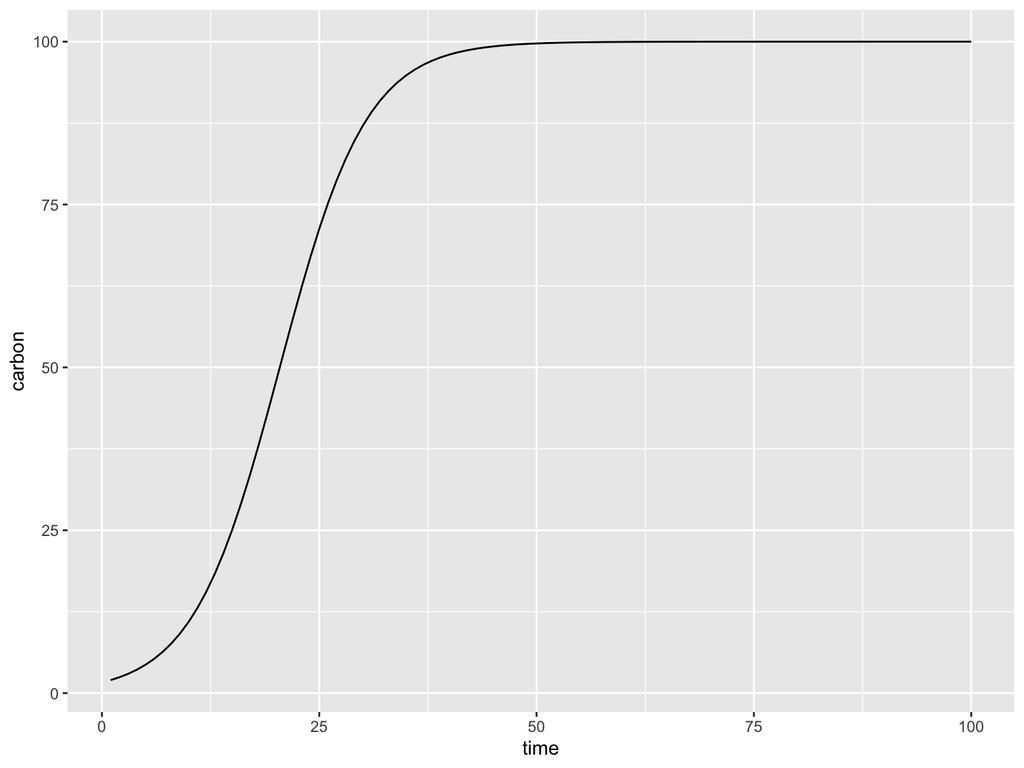

```r
# set parameters
forestparms = list(K=100,r=0.2)

# create a time sequence
tm = seq(from=1,to=100)

# start a small forest
postfire_initial_carbon = 2

# watch it grow
forest = ode(y=postfire_initial_carbon, times=tm, dexppopK, parms=forestparms)

colnames(forest)=c("time","carbon")
ggplot(as.data.frame(forest),aes(time, carbon) )+geom_line()
```

# Endogenous Example - Regular Harvest

Lets consider a regular harvesting of the forest

Lets start with an annual proportional harvest

How would you change the differential equation to implement this - try it!

- modify *dexppopK*
- rerun starting with mature conditions (lets say 30kg C)
- harvest 10% of the forest every year
- run the model for 500 years
- try changing the harvesting rate to see what happens

# My answer

We can include harvesting in our forest with a new parameter **harv** (proportional harvesting rate))

I also changed the variable names to be more meaningful

```r
# fixed amount per year
source("../R/dharvest.R")
dharvest
```

```
## function (Time, biomass, parms)
## {
##     db = parms$r * biomass * (1 - biomass/parms$K) - parms$harv *
##         biomass
##     return(list(db))
## }
```

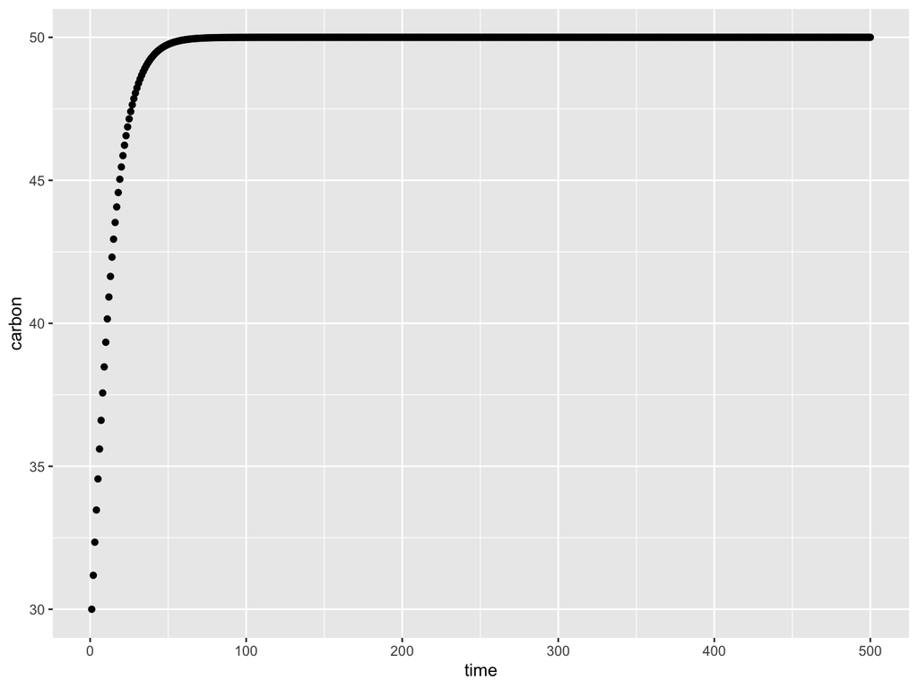

```r
# try it out
tm = seq(from=1, to=500)
Cinitial = 30
gps = list(harv=0.1, K=100, r=0.2)
res = ode(Cinitial,tm, dharvest, gps)
colnames(res)=c("time","carbon")

ggplot(as.data.frame(res), aes(time, carbon))+geom_point()
```

# How does harvesting rate effect carbon

Compute trajectories of forest biomass (or carbon) over time - given different harvesting rates

- create a vector of different harvesting rates that we want to try
- write a wrapper function to run our model and extract trajectories
- run the wrapper function for our harvesting rates
- graph

# My code

```r
# what if we harvest a a much greater rates
# lets vary the harvest rates from 0.0 to 0.4
harvestr = seq(from=0.0, to=0.4, by=0.025)

# save all of the trajectories
# use a wrapper function to just return the carbon trajectories from ODE output
getcarbon = function(Cinitial, tm, harv, K, r, hfunc) {
  gps = list(harv=harv, K=K, r=r)
  res = ode(Cinitial,tm, hfunc, gps)
  colnames(res)=c("time","carbon")
  res=as.data.frame(res)
  return(carbon=res$carbon)
}

# apply this function to all harvest values
res = harvestr %>% map_dfc(~getcarbon( Cinitial=Cinitial, tm=tm, K=100, r=0.2, hfun=dharvest, harv=.x))
# rows are time, columns are carbon for each harvest scenario
colnames(res)=harvestr
res=as.data.frame(res)
res$time=tm
head(res)
```

```
##          0    0.025     0.05    0.075      0.1    0.125     0.15    0.175
## 1 30.00000 30.00000 30.00000 30.00000 30.00000 30.00000 30.00000 30.00000
## 2 34.35985 33.53827 32.73592 31.95234 31.18711 30.43991 29.71018 28.99766
## 3 39.00030 37.22369 35.52436 33.89924 32.34530 30.85973 29.43969 28.08257
## 4 43.84888 41.00637 38.33489 35.82562 33.46995 31.25972 29.18691 27.24404
## 5 48.81781 44.83069 41.13608 37.71711 34.55716 31.64015 28.95045 26.47307
## 6 53.81022 48.63856 43.89691 39.56035 35.60360 32.00148 28.72905 25.76204
##        0.2    0.225     0.25    0.275      0.3    0.325     0.35    0.375
## 1 30.00000 30.00000 30.00000 30.00000 30.00000 30.00000 30.00000 30.00000
## 2 28.30190 27.62251 26.95913 26.31140 25.67895 25.06144 24.45852 23.86986
## 3 26.78574 25.54668 24.36300 23.23238 22.15258 21.12145 20.13690 19.19696
## 4 25.42374 23.71905 22.12332 20.63017 19.23355 17.92771 16.70717 15.56674
## 5 24.19355 22.09813 20.17368 18.40778 16.78868 15.30529 13.94723 12.70474
## 6 23.07692 20.65113 18.46318 16.49273 14.72066 13.12909 11.70139 10.42214
##         0.4 time
## 1 30.000000    1
## 2 23.295141    2
## 3 18.299692    3
## 4 14.501492    4
## 5 11.568716    5
## 6  9.277116    6
```

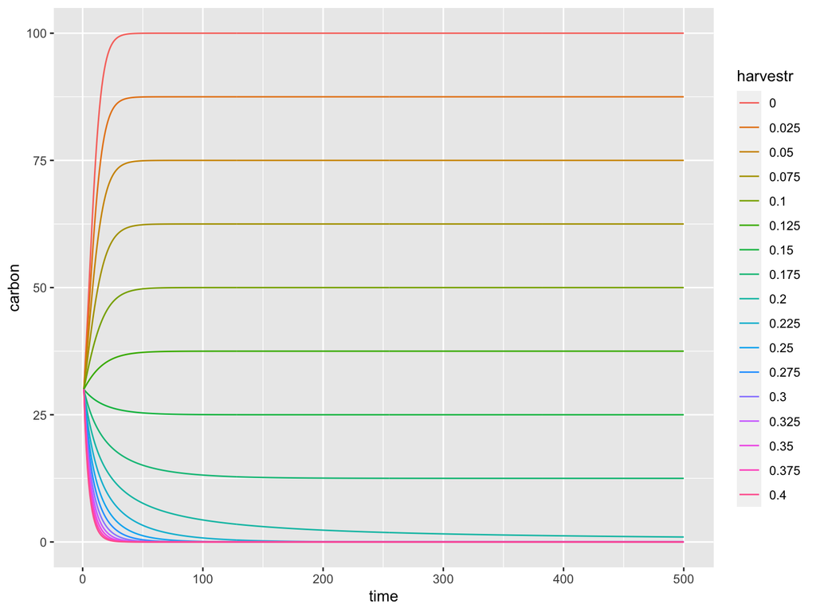

```r
# put in to a form where we can plot
resl = gather(res, key="harvestr",value="carbon", -time)
ggplot(resl,aes(time, carbon, col=harvestr))+geom_line()
```

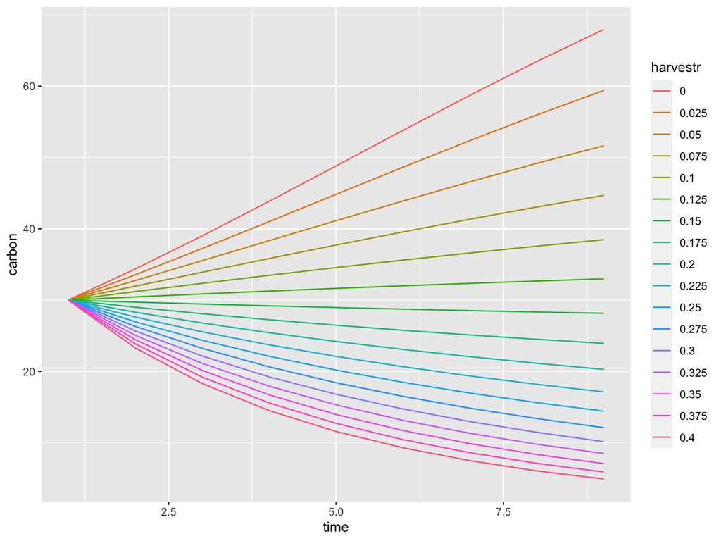

```r
# notice that stable forest value changes with harvest rates

# notes that some forests are not stable - (or forest size goes to zero)

# see this at the beginning - plot the first 10 years
ggplot(subset(resl, time < 10),aes(time, carbon, col=harvestr))+geom_line()
```

# Parameter Interactions

How do different harvest rates interact with different growth rates (and/or) carrying capacity?

Common “type” of question - how does disturbance interact with the properties (parameters) of the system?

Explore on your own

Try different combination of growth and harvest rates…

- Notice how carbon growth changes…
- What does stability mean -
- Can you find parameter sets that lead to a stable non-zero forest

# Sensitivity Analysis

We could do some sensitivity analysis to see how harvest rate, and growth rate interact

Sensitivity of what? What do we care about?

- where forest ends up after 10 years and 50 years (short and long planning horizons)

We will design a function to compute metrics and a wrapper to make this easy

```r
# fixed amount per year
source("../R/dharvest.R")

# compute our two metrics of interest - harvest after 10 and 50 years
# make it general in case we want to use other times
compute_short_long_C = function(carbontime, short=10, long=50) {
 Cshort = carbontime %>% subset(time==short) %>% select(C)
 Clong = carbontime %>% subset(time==long) %>% select(C)
 # use as numeric to clean up
return(list(Cshort=as.numeric(Cshort), Clong=as.numeric(Clong)))}

# now lets get our sample parameters
# lets assume a uniform distribution of harvest rates
# and of normal growth rates
np=200

r = rnorm(mean=0.3, sd=0.05, n=np)
harv = runif(min=0.0, max=0.4, n=np)
K =
X1 = cbind.data.frame(r=r, harv=harv)

# repeat to get our second set of samples
r = rnorm(mean=0.3, sd=0.05, n=np)
harv = runif(min=0.0, max=0.4, n=np)
X2 = cbind.data.frame(r=r, harv=harv)

# create our sobel object and get sets of parameters for running the model

sens_forest = sobolSalt(model = NULL,X1, X2, nboot = 300)
colnames(sens_forest$X)= c("r","harv")

head(sens_forest$X)
```

```
##              r       harv
## [1,] 0.2741549 0.09095369
## [2,] 0.2609564 0.03688524
## [3,] 0.2419774 0.27281047
## [4,] 0.3021799 0.25356560
## [5,] 0.3599014 0.14590568
## [6,] 0.1971629 0.02803123
```

```r
# do a quick test
# try it out
tm = seq(from=1, to=50)
Cinitial = 30
parms = list(r=sens_forest$X[1,1], harv=sens_forest$X[1,2], K=100)

res = ode(y=Cinitial,times=tm, func=dharvest, parms=parms)
res=as.data.frame(res)
colnames(res)=c("time","C")

compute_short_long_C(res)
```

```
## $Cshort
## [1] 54.06412
##
## $Clong
## [1] 66.81361
```

# Build our wrapper function and run for all the parameter sets

```r
# use a wrapper function to just return the carbon trajectories
p_wrapper = function(r,harv, K, Cinitial, simtimes, odefunc, metricfunc) {
    parms = list(r=r, K=K, harv=harv)
    result = ode(y=Cinitial, times=simtimes, func=odefunc, parms=parms)
    result=as.data.frame(result)
   colnames(result)=c("time","C")
  # get metrics
  metrics=metricfunc(result)
  return(metrics)
}

# notice how we added in K, a parameter that we are NOT varying

# try it out
tm = seq(from=1, to=50)
Cinitial = 30


allresults = as.data.frame(sens_forest$X) %>% pmap(p_wrapper, K=100, Cinitial=Cinitial, simtimes=tm, odefunc=dharvest, metricfunc=compute_short_long_C)

# extract out results from pmap into a data frame
allres = allresults %>% map_dfr(`[`,c("Cshort","Clong"))
# clean up the column names
allres = as.data.frame(allres)

head(allres)
```

```
##     Cshort     Clong
## 1 54.06412 66.813613
## 2 68.81010 85.862637
## 3 14.47311  2.335998
## 4 22.96309 16.807733
## 5 52.01550 59.457913
## 6 61.02095 85.742583
```

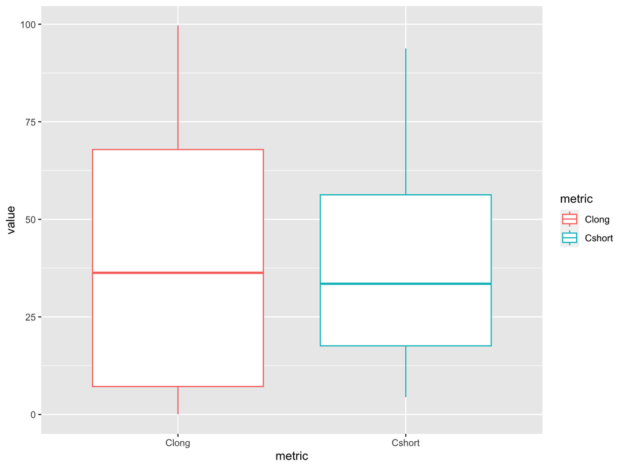

```r
tmp = allres %>% gather(key="metric", value="value")
ggplot(tmp, aes(metric, value, col=metric))+geom_boxplot()
```